# Parameter Recovery GCM

Jana Jarecki & Kilian Sennrich

11 8 2020

```r
#Libraries
pkgs <- c("data.table",
          "tidyverse",
          "Hmisc",
          "psych",
          "qgraph")

lapply(pkgs, library, character.only = TRUE)
```

```r
#Data // l = long; w = wide
data.l <- readRDS("../../data/raw/recovery_results.RDS")
data.l <- data.l[convergence != 1][, convergence := NULL]
data.w <- dcast(
  data = data.l,
  formula = run + discount + nblock + type + row ~ names,
  value.var = c("par", "true_par"))
data.w <- data.w[true_par_lambda == 1]
```

There are 31 cases, where the GCM could not find optimal free parameters.

## 1. What interdependencies can be found between the variables?

In the following, I compile a correlation matrix to see, whether there are interdependencies between different variables. Significant correlation indicates some kind of systematic dependency between the two variables involved. First, “row” and “run” columns are deleted from the data frame, that is because “run” is not expected to have significant influence and because all information of the “row” column if fully covered by the “true_par_lambda” and “true_par_tau” columns. Second, Spearman correlation is used to compile the correlation matrix. The nonparametric method is used, since not all the data is expected to meet criteria for pearson correlation. Third, correlation matrix is transformed to be in a more accessible format. Fourth, significant p-values are filtered. Knowing interdependencies gathers evidence for the decision to plot and test data either marginalized or conditioned. No correction method is used to control for alpha inflation.

```r
#Prepare data for correlation matrix
data.w.cor <- data.w[, -c("row", "run")]

#correlation matrix to check for interdependencies between the variables. Nonparametric method is used, since data did not meet criteria for pearson
cormat <- rcorr(as.matrix(data.w.cor), type = "spearman")
cormat.r <- as.data.frame(t(cormat$r))
cormat.p <- as.data.frame(cormat$P)
data.cor <-data.table(
  Var1 = rownames(cormat.r)[row(cormat.r)[upper.tri(cormat.r)]],
  Var2 = colnames(cormat.r)[col(cormat.r)[upper.tri(cormat.r)]],
  corr=round(cormat.r[upper.tri(cormat.r)],4),
  p = round(cormat.p[upper.tri(cormat.p)],4))

#filter relevant values
data.cor.rel <- data.cor[corr != 0 & corr != 1 & corr != -1 & p < 0.05]
```

### Graphical analysis of the intercorrelations between relevant variables

Correlation plots are drawn to check for partial correlations. Spearman rank correlation is used as the correlation method.

#### correlation plots with qgraph

```r
#subset data
data.qgraph.post <- data.w[,c("par_b0", "par_b1", "par_color", "par_lambda", "par_shape", "par_size", "par_tau")]
data.qgraph.pre <- data.w[, c("discount", "type", "nblock", "true_par_tau")]

#transform into desired format
data.qgraph.post <- cor(data.qgraph.post, use = "pairwise.complete.obs", method = "spearman")
data.qgraph.pre <- cor(data.qgraph.pre, use = "pairwise.complete.obs", method = "spearman")

#graphs and correlation matrices
data.qgraph.post
```

```
##                  par_b0       par_b1   par_color   par_lambda   par_shape
## par_b0      1.000000000 -1.000000000  0.03660214 -0.009057815  0.02135469
## par_b1     -1.000000000  1.000000000 -0.03660214  0.009057815 -0.02135469
## par_color   0.036602144 -0.036602144  1.00000000 -0.159227151 -0.42372679
## par_lambda -0.009057815  0.009057815 -0.15922715  1.000000000 -0.04516085
## par_shape   0.021354695 -0.021354695 -0.42372679 -0.045160848  1.00000000
## par_size   -0.029305008  0.029305008 -0.51679164  0.106894361 -0.35788649
## par_tau     0.027996856 -0.027996856  0.08492270  0.330800434 -0.08029233
##               par_size     par_tau
## par_b0     -0.02930501  0.02799686
## par_b1      0.02930501 -0.02799686
## par_color  -0.51679164  0.08492270
## par_lambda  0.10689436  0.33080043
## par_shape  -0.35788649 -0.08029233
## par_size    1.00000000 -0.10136930
## par_tau    -0.10136930  1.00000000
```

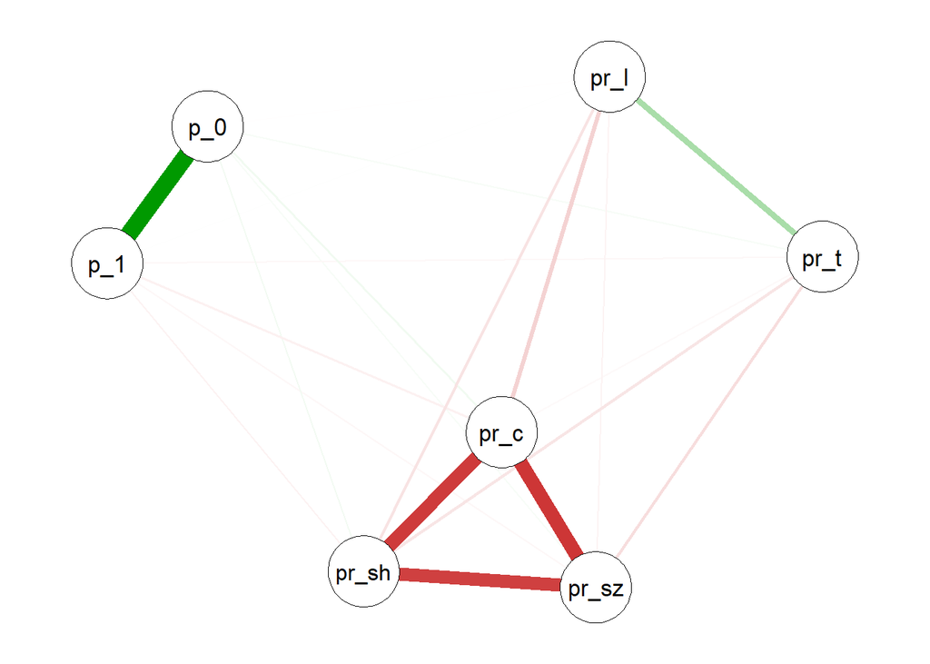

```r
qgraph(data.qgraph.post, graph = "pcor", layout = "spring")
```

```r
data.qgraph.pre
```

```
##                   discount          type       nblock  true_par_tau
## discount      1.0000000000 -0.0008559165 0.0001392370 -0.0002040262
## type         -0.0008559165  1.0000000000 0.0006113982 -0.0014207818
## nblock        0.0001392370  0.0006113982 1.0000000000  0.0011004350
## true_par_tau -0.0002040262 -0.0014207818 0.0011004350  1.0000000000
```

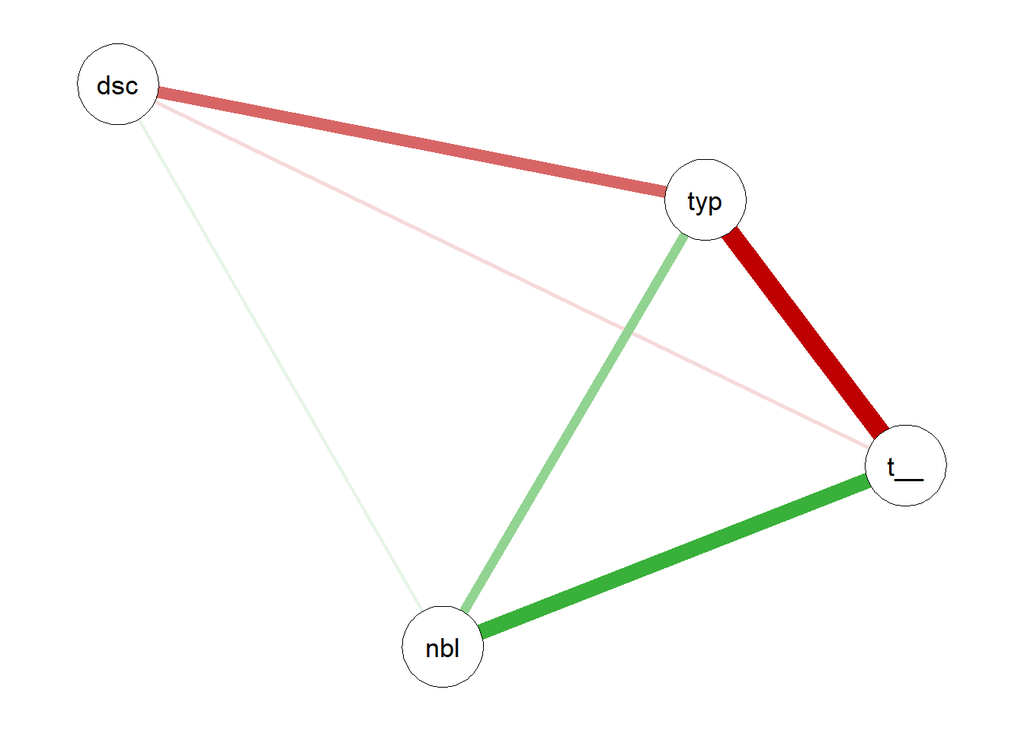

```r
qgraph(data.qgraph.pre, graph = "pcor", layout = "spring")
```

### Testing wether discount, nblock and type have significant influence on the recovery of tau.

```r
#dataframe with all possible combinations
combinations <- expand.grid(
  disc1 = c(0, 8),
  disc2 = c(0, 8),
  nblo1 = c(30, 100),
  nblo2 = c(30, 100),
  type1 = 1:6,
  type2 = 1:6)

#dataframe with all combinations of interest
combinations <- subset(
  combinations,
  disc1 != disc2 &
  nblo1 == nblo2 &
  type1 == type2 |
  disc1 == disc2 &
  nblo1 != nblo2 &
  type1 == type2 |
  disc1 == disc2 &
  nblo1 == nblo2 &
  type1 != type2,
  drop = TRUE)

results <- list()
l = 1

for (i in 1:nrow(combinations)) {
  #filter every row separatly and subset values
  row <- combinations[i,]
  disc1 <- as.double(row["disc1"])
  disc2 <- as.double(row["disc2"])
  nblo1 <- as.double(row["nblo1"])
  nblo2 <- as.double(row["nblo2"])
  type1 <- as.double(row["type1"])
  type2 <- as.double(row["type2"])

  #make components for rtest
  component_1 <- data.w[
    discount == disc1 &
    nblock == nblo1 &
    type == type1]
  component_2 <- data.w[
    discount == disc2 &
    nblock == nblo2 &
    type == type2]

  #spearman and pearson correlations
  cor.c1.spearman <- cor(
    component_1$par_tau,
    component_1$true_par_tau,
    method = "spearman")
  cor.c2.spearman <- cor(
    component_2$par_tau,
    component_2$true_par_tau,
    method = "spearman")
  cor.c1.pearson <- cor(
    component_1$par_tau,
    component_1$true_par_tau,
    method = "pearson")
  cor.c2.pearson <- cor(
    component_2$par_tau,
    component_2$true_par_tau,
    method = "pearson")

  #correlation tests for spearman and pearson
  rtest.spearman <- r.test(
    n = nrow(component_1),
    n2 = nrow(component_2),
    r12 = cor.c1.spearman,
    r34 = cor.c2.spearman)
  rtest.pearson <- r.test(
    n = nrow(component_1),
    n2 = nrow(component_2),
    r12 = cor.c1.pearson,
    r34 = cor.c2.pearson)

  #list with all information of interest
  results[[l]] <- data.table(
    discount_1 = disc1,
    discount_2 = disc2,
    nblock_1 = nblo1,
    nblock_2 = nblo2,
    type_1 = type1,
    type_2 = type2,
    spearman_1 = cor.c1.spearman,
    spearman_2 = cor.c2.spearman,
    pearson_1 = cor.c1.pearson,
    pearson_2 = cor.c2.pearson,
    mse_1 = mean((component_1$true_par_tau - component_1$par_tau)^2),
    mse_2 = mean((component_2$true_par_tau - component_2$par_tau)^2),
    p.spearman = round(rtest.spearman$p, 4),
    z.spearman = round(rtest.spearman$z, 4),
    p.pearson = round(rtest.pearson$p, 4),
    z.pearson = round(rtest.pearson$z, 4)
  )
  l = l + 1
}

#convert results into data.table
results <- rbindlist(results)
results <- results[p.spearman < 0.05 | p.pearson < 0.05][order(p.pearson)][-seq(2, 68, by = 2)]

# adjust p-values
results$adj_spearman <- p.adjust(
  results$p.spearman,
  method = "bonferroni")
results$adj_pearson <- p.adjust(
  results$p.pearson,
  method = "bonferroni")

#possibility for alpha inflation error
1 - (1 - 0.05)^nrow(results)
```

```
## [1] 0.8251754
```

```r
#pvalue after bonferroni
0.05/34
```

```
## [1] 0.001470588
```

```r
results[adj_spearman < 0.05]
```

```
##    discount_1 discount_2 nblock_1 nblock_2 type_1 type_2 spearman_1 spearman_2
## 1:          0          0      100      100      6      3  0.5146905  0.7137198
## 2:          0          0      100      100      3      2  0.7137198  0.4959618
## 3:          0          0       30       30      4      3  0.5566556  0.7245025
## 4:          8          8      100      100      3      1  0.6749101  0.4852507
## 5:          0          0      100      100      3      1  0.7137198  0.4944124
## 6:          0          0       30       30      3      1  0.7245025  0.5102281
##    pearson_1 pearson_2    mse_1    mse_2 p.spearman z.spearman p.pearson
## 1: 0.2026163 0.5076621 5.302726 4.216582      1e-04     3.9682    0.0000
## 2: 0.5076621 0.3556961 4.216582 7.622096      0e+00     4.2747    0.0222
## 3: 0.3865937 0.4815283 1.322937 2.786341      4e-04     3.5169    0.1540
## 4: 0.5067292 0.4214180 4.222589 4.354446      4e-04     3.5295    0.1848
## 5: 0.5076621 0.4235444 4.216582 3.945488      0e+00     4.2925    0.1906
## 6: 0.4815283 0.4179196 2.786341 3.763645      0e+00     4.3105    0.3312
##    z.pearson adj_spearman adj_pearson
## 1:    4.3153       0.0034      0.0000
## 2:    2.2864       0.0000      0.7548
## 3:    1.4256       0.0136      1.0000
## 4:    1.3260       0.0136      1.0000
## 5:    1.3087       0.0000      1.0000
## 6:    0.9717       0.0000      1.0000
```

```r
results[adj_pearson < 0.05]
```

```
##    discount_1 discount_2 nblock_1 nblock_2 type_1 type_2 spearman_1 spearman_2
## 1:          0          0      100      100      6      3  0.5146905  0.7137198
## 2:          0          0      100      100      6      4  0.5146905  0.6588408
## 3:          0          0       30       30      6      3  0.5908744  0.7245025
##    pearson_1 pearson_2    mse_1    mse_2 p.spearman z.spearman p.pearson
## 1: 0.2026163 0.5076621 5.302726 4.216582     0.0001     3.9682    0.0000
## 2: 0.2026163 0.4915699 5.302726 2.610423     0.0069     2.7013    0.0001
## 3: 0.2538277 0.4815283 5.419539 2.786341     0.0038     2.8960    0.0012
##    z.pearson adj_spearman adj_pearson
## 1:    4.3153       0.0034      0.0000
## 2:    4.0539       0.2346      0.0034
## 3:    3.2296       0.1292      0.0408
```

Limitations: To even get significant results, i first filtered the pvalues that are significant without bonferroni. Only in a second step i corrected the pvalues with bonferroni. I think the results are still accurate, because it pretty much goes with the visual results we obtain further down the page. I think to report it would be good to present a correlation table with corrected and uncorrected p values. Dividing every pvalue trough 34 results in a p value of 0.00147 that has to be passed by every group. Bonferroni is in my eyes a tradeoff between understanding the data propperly and statistical accuracy. I think in our case its ok to take a possibility of p = 0.83 to at least have one result that wrongfully reports statistical significance where there is none.

### Understanding the recovery of type 1

```r
#Rendered with dimension "color" == 0.98
data.type1 <- readRDS("../../data/raw/results_type1.RDS")
data.type1 <- data.type1[convergence != 1][, convergence := NULL]
data.type1 <- dcast(
  data = data.type1,
  formula = run + discount + nblock + type + row ~ names,
  value.var = c("par", "true_par"))

data.type1 <- data.type1 %>%
  group_by(discount, nblock, true_par_tau) %>%
  mutate(med_type1_new = median(par_color))

#Rendered with dimension "color" == 0.33
dat.type1.orig <- data.w[type == 1]

dat.type1.orig <- dat.type1.orig %>%
  group_by(discount, nblock, true_par_tau) %>%
  mutate(med_type1 = median(par_color))
```

#### true_par_color == 0.98

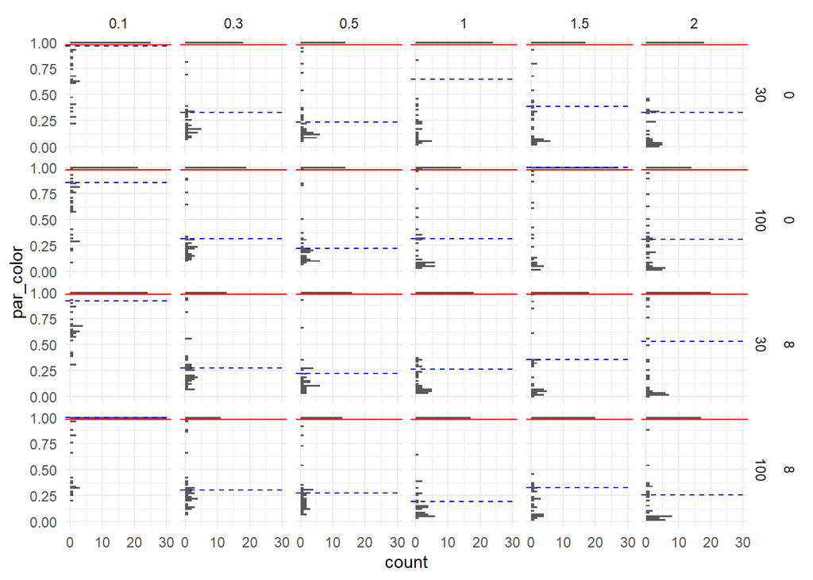

```r
ggplot(
  data = data.type1,
  mapping = aes(y = par_color), bins)+
  geom_histogram(bins = 60) +
  geom_hline(aes(yintercept = true_par_color), color = "red") +
  geom_hline(aes(yintercept = med_type1_new), color="blue", linetype="dashed")+
  facet_grid(discount + nblock ~ true_par_tau) +
  theme_minimal()
```

#### true_par_color == 0.33

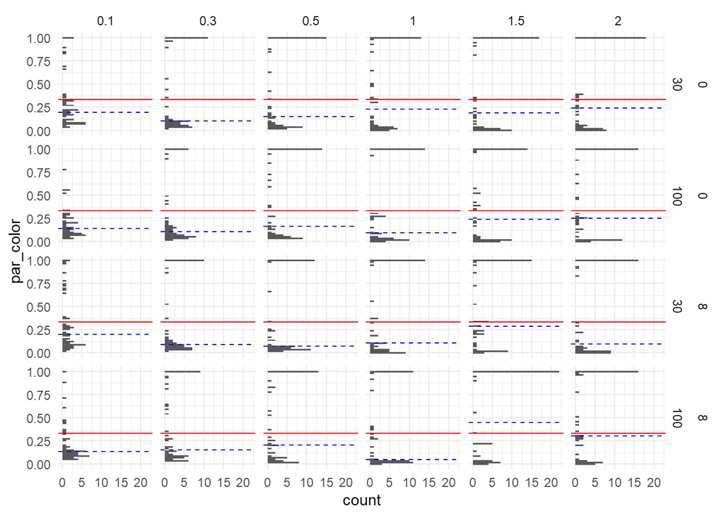

```r
ggplot(
  data = dat.type1.orig,
  mapping = aes(y = par_color))+
  geom_histogram(bins = 60) +
  geom_hline(aes(yintercept = true_par_color), color = "red") +
  geom_hline(aes(yintercept = med_type1), color="blue", linetype="dashed")+
  facet_grid(discount + nblock ~ true_par_tau) +
  theme_minimal()
```

### Graphical analysis of the recovery of all parameters

For every parameter, dependencies on other variables will be checked. Depending on this, the plots are designed as meaningful as possible.

#### b0

```r
#recovery of b0
data.cor.rel[Var1 == "par_b0" | Var2 == "par_b0"]
```

```
##      Var1      Var2    corr      p
## 1:   type    par_b0  0.0321 0.0065
## 2: par_b0 par_color  0.0366 0.0019
## 3: par_b0  par_size -0.0293 0.0130
## 4: par_b0   par_tau  0.0280 0.0176
```

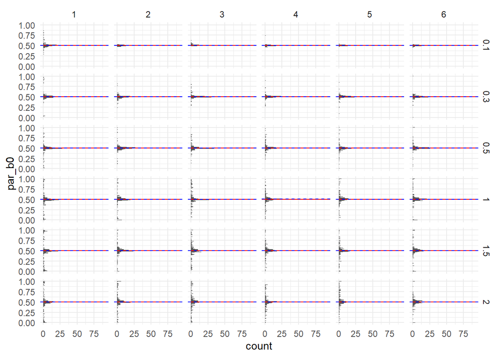

```r
data.w.b0 <- data.w %>%
  group_by(type, true_par_tau) %>%
  mutate(med_b0 = median(par_b0))

ggplot(data = data.w.b0,
       mapping = aes(y = par_b0)) +
  geom_histogram(bins = 100) +
  geom_hline(aes(yintercept = true_par_b0), color = "red") +
  geom_hline(aes(yintercept = med_b0), color="blue", linetype="dashed")+
  facet_grid(true_par_tau ~ type)+
  theme_minimal()
```

#### b1

```r
#recovery of b1
data.cor.rel[Var1 == "par_b1" | Var2 == "par_b1"]
```

```
##      Var1      Var2    corr      p
## 1:   type    par_b1 -0.0321 0.0065
## 2: par_b1 par_color -0.0366 0.0019
## 3: par_b1  par_size  0.0293 0.0130
## 4: par_b1   par_tau -0.0280 0.0176
```

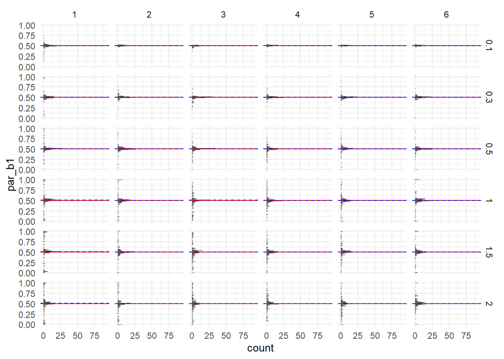

```r
data.w.b1 <- data.w %>%
  group_by(type, true_par_tau) %>%
  mutate(med_b1 = median(par_b1))

ggplot(data = data.w.b1,
       mapping = aes(y = par_b1)) +
  geom_histogram(bins = 100) +
  geom_hline(aes(yintercept = true_par_b1), color = "red") +
  geom_hline(aes(yintercept = med_b1), color="blue", linetype="dashed")+
  facet_grid(true_par_tau ~ type) +
  theme_minimal()
```

#### size

```r
#recovery of size
data.cor.rel[Var1 == "par_size" | Var2 == "par_size"]
```

```
##          Var1         Var2    corr     p
## 1:       type     par_size  0.0742 0.000
## 2:     par_b0     par_size -0.0293 0.013
## 3:     par_b1     par_size  0.0293 0.013
## 4:  par_color     par_size -0.5168 0.000
## 5: par_lambda     par_size  0.1069 0.000
## 6:  par_shape     par_size -0.3579 0.000
## 7:   par_size      par_tau -0.1014 0.000
## 8:   par_size true_par_tau -0.0243 0.039
```

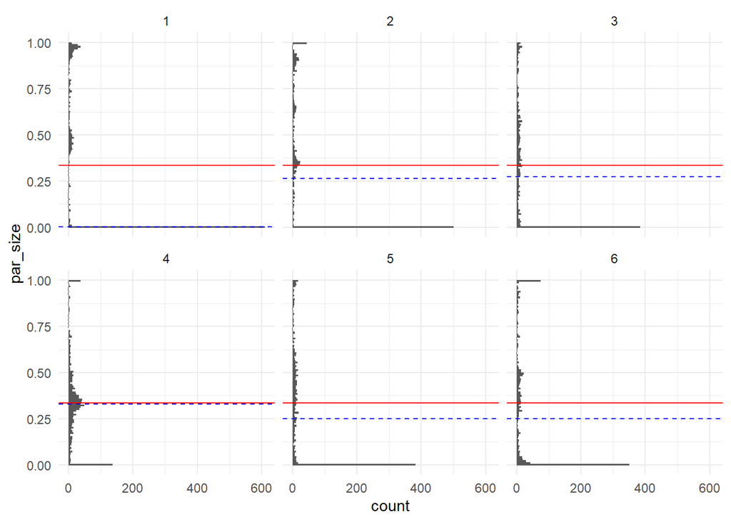

```r
data.w.size <- data.w %>%
  group_by(type) %>%
  mutate(med_size = median(par_size))

ggplot(data = data.w.size,
       mapping = aes(y = par_size)) +
  geom_histogram(bins = 100) +
  geom_hline(aes(yintercept = true_par_size), color = "red") +
  geom_hline(aes(yintercept = med_size, group = type), color="blue", linetype="dashed")+
  facet_wrap(~type)+
  theme_minimal()
```

#### color

```r
#recovery of color
data.cor.rel[Var1 == "par_color" | Var2 == "par_color"]
```

```
##         Var1         Var2    corr      p
## 1:    nblock    par_color  0.0316 0.0074
## 2:    par_b0    par_color  0.0366 0.0019
## 3:    par_b1    par_color -0.0366 0.0019
## 4: par_color   par_lambda -0.1592 0.0000
## 5: par_color    par_shape -0.4237 0.0000
## 6: par_color     par_size -0.5168 0.0000
## 7: par_color      par_tau  0.0849 0.0000
## 8: par_color true_par_tau -0.0326 0.0057
```

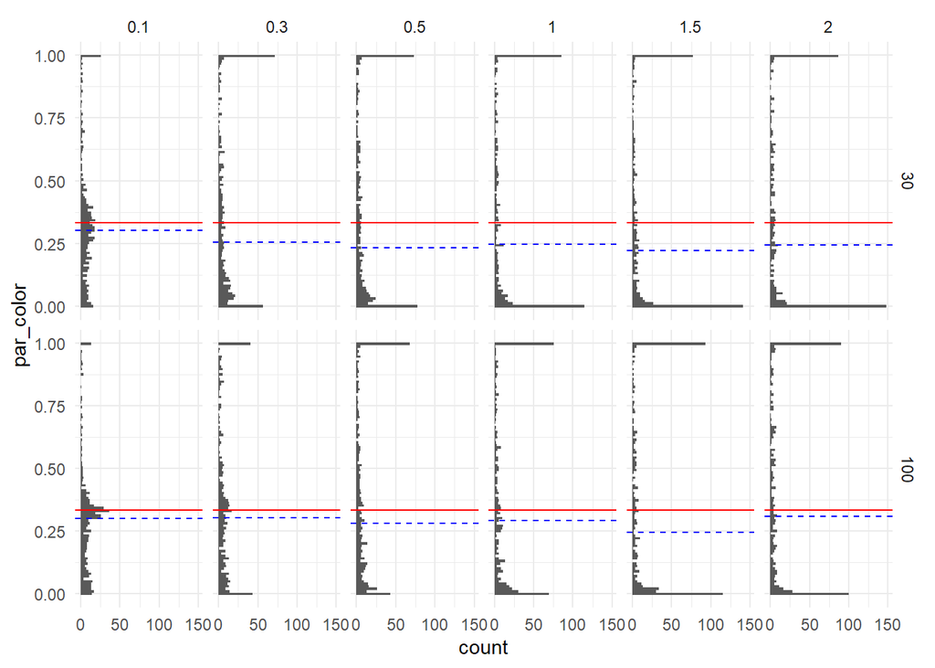

```r
data.w.color <- data.w %>%
  group_by(nblock, true_par_lambda, true_par_tau) %>%
  mutate(med_color = median(par_color))

ggplot(data = data.w.color,
       mapping = aes(y = par_color)) +
  geom_histogram(bins = 100) +
  geom_hline(aes(yintercept = true_par_color), color = "red") +
  geom_hline(aes(yintercept = med_color), color="blue", linetype="dashed")+
  facet_grid( nblock ~ true_par_tau) +
  theme_minimal()
```

#### shape

```r
#recovery of shape
data.cor.rel[Var1 == "par_shape" | Var2 == "par_shape"]
```

```
##          Var1         Var2    corr     p
## 1:       type    par_shape  0.0587 0e+00
## 2:  par_color    par_shape -0.4237 0e+00
## 3: par_lambda    par_shape -0.0452 1e-04
## 4:  par_shape     par_size -0.3579 0e+00
## 5:  par_shape      par_tau -0.0803 0e+00
## 6:  par_shape true_par_tau -0.0883 0e+00
```

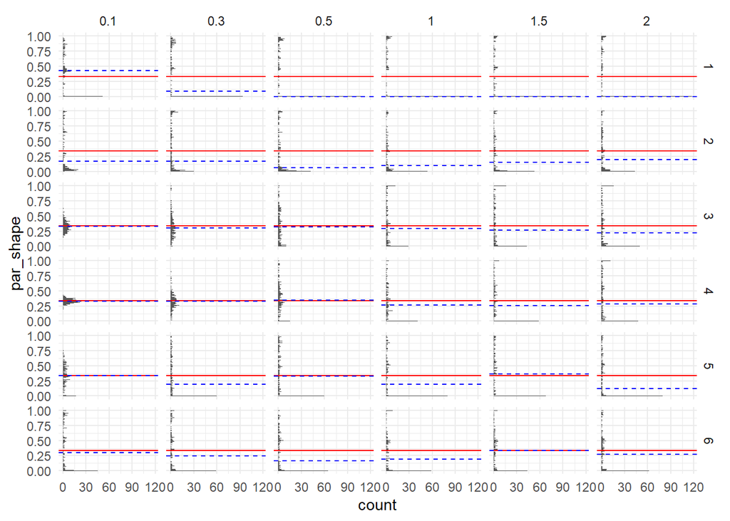

```r
data.w.shape <- data.w %>%
  group_by(true_par_tau, true_par_lambda, type) %>%
  mutate(med_shape = median(par_shape))

ggplot(data = data.w.shape,
       mapping = aes(y = par_shape)) +
  geom_histogram(bins = 100) +
  geom_hline(aes(yintercept = true_par_shape), color = "red") +
  geom_hline(aes(yintercept = med_shape), color="blue", linetype="dashed") +
  facet_grid(type ~ true_par_tau) +
  theme_minimal()
```

#### lambda

```r
#recovery of lambda
data.cor.rel[Var1 == "par_lambda" | Var2 == "par_lambda"]
```

```
##          Var1       Var2    corr     p
## 1:       type par_lambda -0.1086 0e+00
## 2:  par_color par_lambda -0.1592 0e+00
## 3: par_lambda  par_shape -0.0452 1e-04
## 4: par_lambda   par_size  0.1069 0e+00
## 5: par_lambda    par_tau  0.3308 0e+00
```

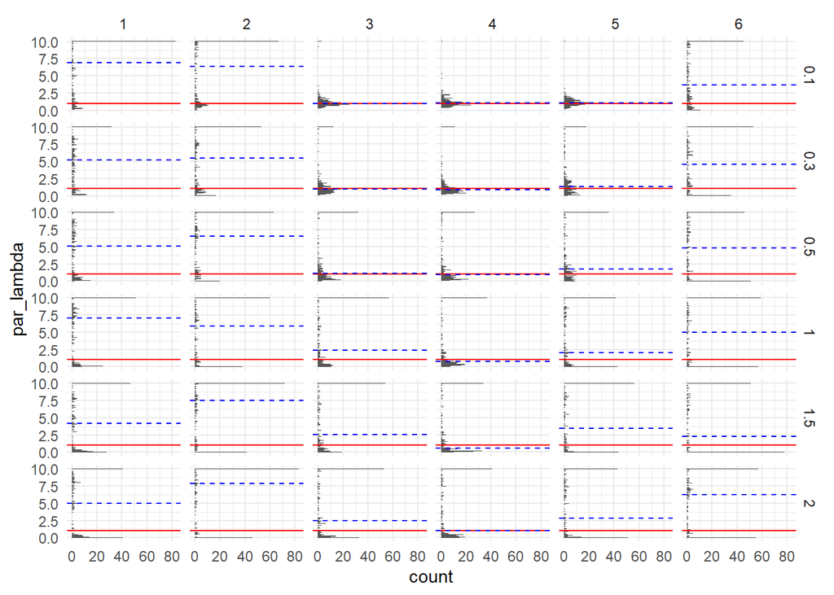

```r
data.w.lambda <- data.w %>%
  group_by(true_par_lambda, true_par_tau, type) %>%
  mutate(med_lambda = median(par_lambda))

ggplot(data = data.w.lambda,
       mapping = aes(y = par_lambda)) +
  geom_histogram(bins = 100) +
  geom_hline(aes(yintercept = true_par_lambda), color = "red") +
  geom_hline(aes(yintercept = med_lambda), color="blue", linetype="dashed")+
  facet_grid(true_par_tau ~ type)+
  theme_minimal()
```

#### tau

```r
#recovery of tau
data.cor.rel[Var1 == "par_tau" | Var2 == "par_tau"]
```

```
##           Var1         Var2    corr      p
##  1:   discount      par_tau  0.0258 0.0285
##  2:     nblock      par_tau  0.0388 0.0010
##  3:       type      par_tau -0.0503 0.0000
##  4:     par_b0      par_tau  0.0280 0.0176
##  5:     par_b1      par_tau -0.0280 0.0176
##  6:  par_color      par_tau  0.0849 0.0000
##  7: par_lambda      par_tau  0.3308 0.0000
##  8:  par_shape      par_tau -0.0803 0.0000
##  9:   par_size      par_tau -0.1014 0.0000
## 10:    par_tau true_par_tau  0.5942 0.0000
```

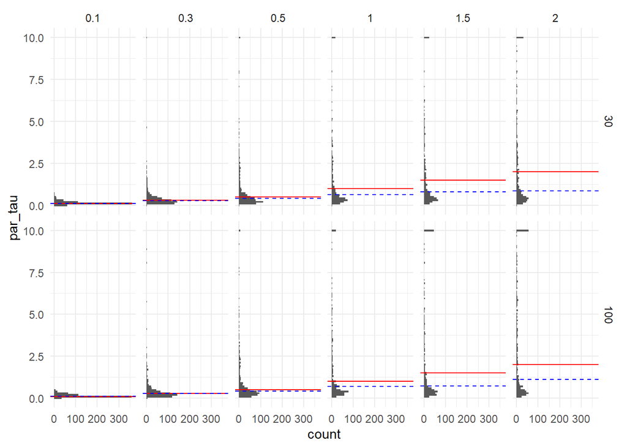

```r
data.w.tau <- data.w %>%
  group_by(true_par_tau, nblock) %>%
  mutate(med_tau = median(par_tau))

ggplot(data = data.w.tau,
       mapping = aes(y = par_tau)) +
  geom_histogram(bins = 100) +
  geom_hline(aes(yintercept = true_par_tau), color = "red") +
  geom_hline(aes(yintercept = med_tau), color="blue", linetype="dashed")+
  facet_grid(nblock ~ true_par_tau) +
  theme_minimal()
```

## 2. Impact of omitting the first 0 and 8 rows on recovering tau

#### violin plot for “discount”

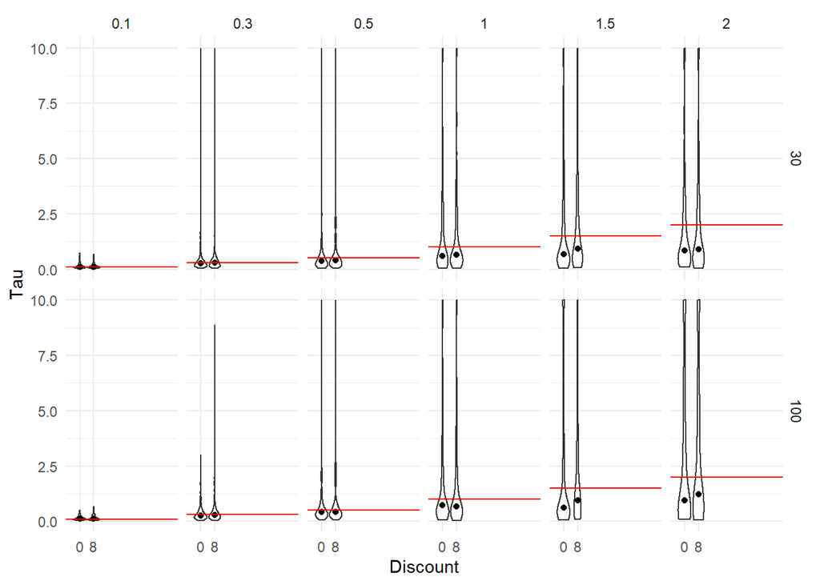

```r
#violin plots for discount per par_tau
ggplot(data = data.w,
       mapping = aes(x = as.factor(discount),
                     y = par_tau)) +
  geom_violin(width = 0.9) +
  stat_summary(fun = "median",
               geom = "point") +
  geom_line(aes(x = discount,
                y = true_par_tau),
            color = "red",
            size = 0.5) +
  facet_grid(nblock ~ true_par_tau)+
  ylim(0, 10) +
  xlab("Discount") +
  ylab("Tau") +
  theme_minimal()
```

#### line plot for “discount”

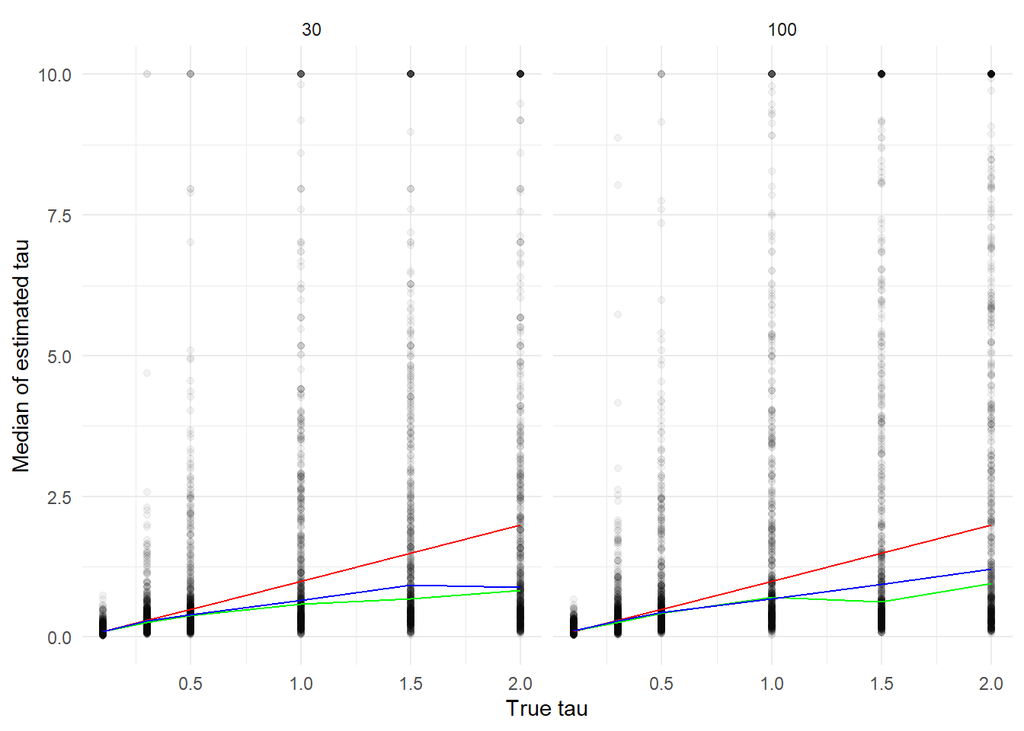

```r
# line plot
ggplot(data = data.w,
       mapping = aes(x = true_par_tau,
                     y = par_tau)) +
  geom_point(aes(x = true_par_tau,
                 y = par_tau),
             alpha = 1 / 20) +
  geom_line(aes(x = true_par_tau,
                y = true_par_tau),
            color = "red") +
  stat_summary(aes(group = discount),
               fun = median,
               geom = "line",
               color = c(rep("green", 6), #discount = 0
                         rep("blue", 6),  #discount = 8
                         rep("green", 6), #discount = 0
                         rep("blue", 6)   #discount = 8
                         ))+
  facet_wrap(~nblock) +
  ylim(0,10) +
  xlab("True tau") +
  ylab("Median of estimated tau") +
  theme_minimal()
```

## 3. Impact of training with multiple blocks on recovery of tau

#### violinplot for “nblock”

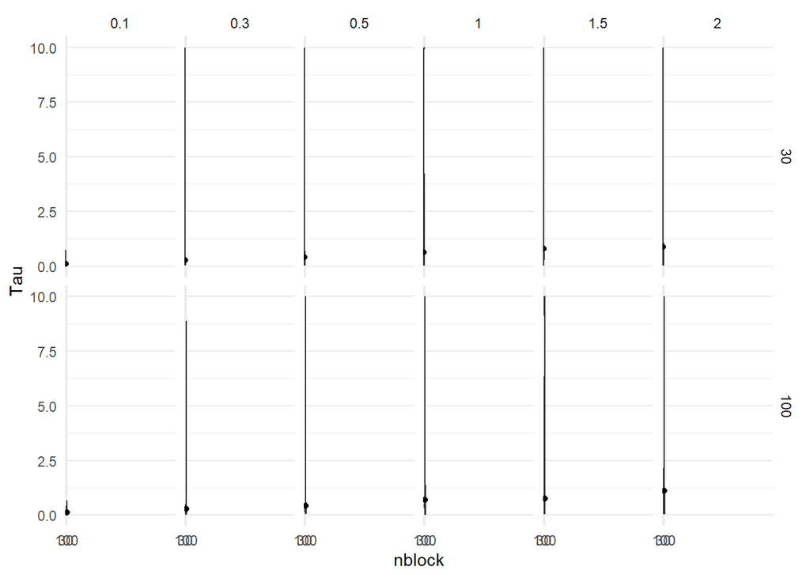

```r
#violin plots for nblock per par_tau
ggplot(data = data.w,
       mapping = aes(x = as.factor(nblock),
                     y = par_tau)) +
  geom_violin(width = 0.9) +
  stat_summary(fun = "median",
               geom = "point") +
  geom_line(aes(x = nblock,
                y = true_par_tau),
            color = "red",
            size = 0.5) +
  facet_grid(nblock ~ true_par_tau)+
  ylim(0, 10) +
  xlab("nblock") +
  ylab("Tau") +
  theme_minimal()
```

#### line plot for “nblock”

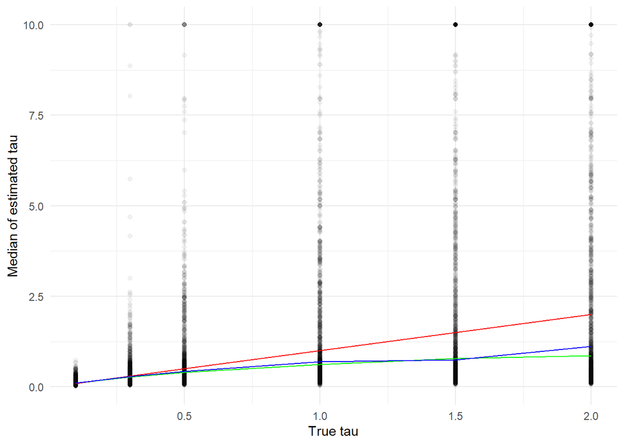

```r
# line plot
ggplot(data = data.w,
       mapping = aes(x = true_par_tau,
                     y = par_tau)) +
  geom_point(aes(x = true_par_tau,
                 y = par_tau),
             alpha = 1 / 20) +
  geom_line(aes(x = true_par_tau,
                y = true_par_tau),
            color = "red") +
  stat_summary(aes(group = nblock),
               fun = median,
               geom = "line",
               color = c(rep("green", 6),  #nblock = 30
                         rep("blue", 6)    #nblock = 100
                         ))+
  ylim(0,10) +
  xlab("True tau") +
  ylab("Median of estimated tau") +
  theme_minimal()
```

## 4. ability of the GCM to grasp the difficulty of the categories on the tau parameter

#### violinplot for “type”

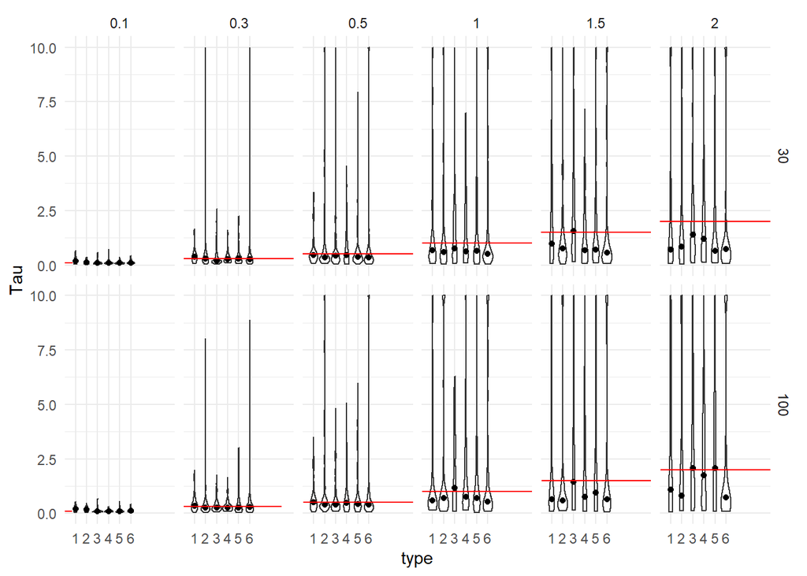

```r
#violin plots for par_tau per type
ggplot(data = data.w,
       mapping = aes(x = as.factor(type),
                     y = par_tau)) +
  geom_violin(width = 0.9) +
  stat_summary(fun = "median",
               geom = "point") +
  geom_line(aes(x = par_tau,
                y = true_par_tau),
            color = "red",
            size = 0.5) +
  facet_grid(nblock ~ true_par_tau)+
  ylim(0, 10) +
  xlab("type") +
  ylab("Tau") +
  theme_minimal()
```

#### lineplot for “type”

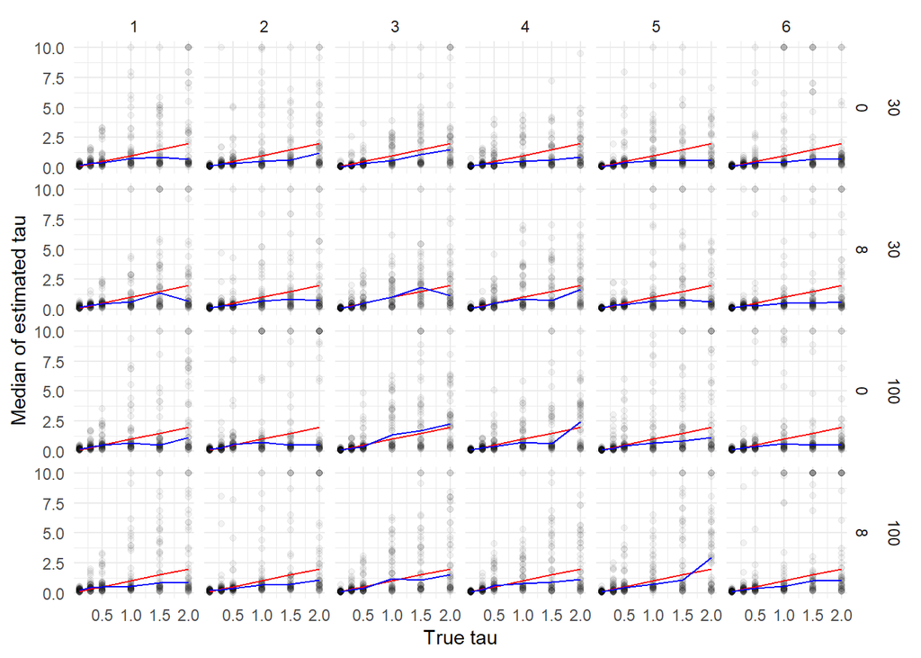

```r
# line plot
ggplot(data = data.w,
       mapping = aes(x = true_par_tau,
                     y = par_tau)) +
  geom_point(aes(x = true_par_tau,
                 y = par_tau),
             alpha = 1 / 20) +
  geom_line(aes(x = true_par_tau,
                y = true_par_tau),
            color = "red") +
  stat_summary(aes(group = type),
               fun = median,
               geom = "line",
               color = c(rep("blue", 144)
                         ))+
  facet_grid(nblock + discount ~ type)+
  ylim(0,10) +
  xlab("True tau") +
  ylab("Median of estimated tau") +
  theme_minimal()
```

## 5. Influence of Lambda on the recovery of Tau

Lambda, the speed of learning (sensitivity) is considered to have a positive impact on the recovery of Tau. When a person learns quicker, the recovery of the prabability of implementing an action should be better especially with bigger Tau values.No significant dependencies on true_par_lambda can be found.

**Graphical analysis**

#### violin plot for “lambda”

[figure not shown]

```r
#violin plots for true lambda per par_tau
ggplot(data = data.w,
       mapping = aes(x = as.factor(true_par_lambda),
                     y = par_tau)) +
  geom_violin(width = 0.9) +
  stat_summary(fun = "median",
               geom = "point") +
  geom_line(aes(x = par_tau,
                y = true_par_tau),
            color = "red",
            size = 0.5) +
  facet_grid(nblock ~ true_par_tau)+
  ylim(0, 10) +
  xlab("Lambda") +
  ylab("Tau") +
  theme_minimal()
```

#### lineplot for “lambda”

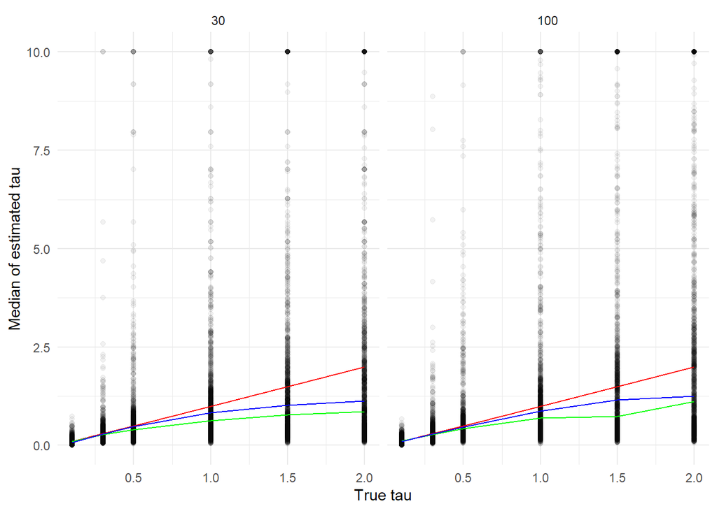

```r
# line plot
ggplot(data = data.w,
       mapping = aes(x = true_par_tau,
                     y = par_tau)) +
  geom_point(aes(x = true_par_tau,
                 y = par_tau),
             alpha = 1 / 20) +
  geom_line(aes(x = true_par_tau,
                y = true_par_tau),
            color = "red") +
  stat_summary(aes(group = true_par_lambda),
               fun = median,
               geom = "line",
               color = c(rep("green", 6),  #lambda = 1
                         rep("blue", 6),   #lambda = 5
                         rep("green", 6),  #lambda = 1
                         rep("blue", 6)    #lambda = 5
                         ))+
  facet_wrap(~nblock)+
  ylim(0,10) +
  xlab("True tau") +
  ylab("Median of estimated tau") +
  theme_minimal()
```